# R Notebook

```r
setwd("/Users/Large_Data/Final_Data")
test <- read.csv(file = '202001.csv')
head(test)
```

|  | Year | Quarter | Month | DayofMonth | DayOfWeek | FlightDate | Reporting_Airline | DOT_ID_Reporting_Airline | IATA_CODE_Reporting_Airline | Tail_Number | Flight_Number_Reporting_Airline | OriginAirportID | OriginAirportSeqID | OriginCityMarketID | Origin | OriginCityName | OriginState | OriginStateFips | OriginStateName | OriginWac | DestAirportID | DestAirportSeqID | DestCityMarketID | Dest | DestCityName | DestState | DestStateFips | DestStateName | DestWac | … |
| --- | --- | --- | --- | --- | --- | --- | --- | --- | --- | --- | --- | --- | --- | --- | --- | --- | --- | --- | --- | --- | --- | --- | --- | --- | --- | --- | --- | --- | --- | --- |
| 1 | 2020 | 1 | 1 | 1 | 3 | 2020-01-01 | WN | 19393 | WN | N951WN | 5888 | 13891 | 1389101 | 32575 | ONT | Ontario, CA | CA | 6 | California | 91 | 14771 | 1477104 | 32457 | SFO | San Francisco, CA | CA | 6 | California | 91 | … |
| 2 | 2020 | 1 | 1 | 1 | 3 | 2020-01-01 | WN | 19393 | WN | N467WN | 6276 | 13891 | 1389101 | 32575 | ONT | Ontario, CA | CA | 6 | California | 91 | 14771 | 1477104 | 32457 | SFO | San Francisco, CA | CA | 6 | California | 91 | … |
| 3 | 2020 | 1 | 1 | 1 | 3 | 2020-01-01 | WN | 19393 | WN | N7885A | 4598 | 13891 | 1389101 | 32575 | ONT | Ontario, CA | CA | 6 | California | 91 | 14831 | 1483106 | 32457 | SJC | San Jose, CA | CA | 6 | California | 91 | … |
| 4 | 2020 | 1 | 1 | 1 | 3 | 2020-01-01 | WN | 19393 | WN | N551WN | 4761 | 13891 | 1389101 | 32575 | ONT | Ontario, CA | CA | 6 | California | 91 | 14831 | 1483106 | 32457 | SJC | San Jose, CA | CA | 6 | California | 91 | … |
| 5 | 2020 | 1 | 1 | 1 | 3 | 2020-01-01 | WN | 19393 | WN | N968WN | 5162 | 13891 | 1389101 | 32575 | ONT | Ontario, CA | CA | 6 | California | 91 | 14831 | 1483106 | 32457 | SJC | San Jose, CA | CA | 6 | California | 91 | … |
| 6 | 2020 | 1 | 1 | 1 | 3 | 2020-01-01 | WN | 19393 | WN | N7856A | 5684 | 13891 | 1389101 | 32575 | ONT | Ontario, CA | CA | 6 | California | 91 | 14831 | 1483106 | 32457 | SJC | San Jose, CA | CA | 6 | California | 91 | … |

Variables of our interest: FlightDate 2018-01-02 IATA_CODE_Reporting_Airline e.g. AA UA Flight_Number_Reporting_Airline 588 Origin JFK Dest SFO DepDelayMinutes <15 -> =0 DepTimeBlk 1100-1159 ArrDelayMinutes ArrTimeBlk Cancelled 0/1 Diverted 0/1 Distance every 250

Airports: EWR Airplines: AA Overall Cancellation Delay Total 117 months 12*9+9

```r
#library(dplyr)
```

```
There were 12 warnings (use warnings() to see them)
```

```r
#library(data.table)
path = "/Users/Large_Data/Final_Data"
pattern = '*.csv'
files = list.files(path, pattern, full.names = TRUE)
ap.numflights.df <- data.frame(ORIGIN=c('EWR','JFK'), n=c(0,0))
al.numflights.df <- data.frame(IATA_CODE_REPORTING_AIRLINE=c('AA','UA'), n=c(0,0))
dep.timeblk.numflights.df <- data.frame(DEPTIMEBLK=c('1300-1359','2000-2059'), n=c(0,0))
arr.timeblk.numflights.df <- data.frame(ARRTIMEBLK=c('1300-1359','2000-2059'), n=c(0,0))

num.total <- NULL
num.cancel <- NULL
num.ontime <- NULL #dep delay<=15min
avg.delay <- NULL

#read.all.files = do.call(rbind, lapply(files, function(x) {print(x);fread(x, stringsAsFactors = FALSE)}))
for (file in files){
  # read one file at a time from files
  df <- fread(file=file,sep = ",", stringsAsFactors = FALSE, header = TRUE)
  #df <- read.csv(file=file)
  names(df) <- toupper(names(df))
  #colnames(df) <-toupper(colnames(df))
  if ('FL_DATE' %in% names(df)){
    df <- df[,c('OP_UNIQUE_CARRIER', 'ORIGIN', 'DEST', 'DEP_DELAY_NEW', 'DEP_TIME_BLK', 'ARR_DELAY_NEW', 'ARR_TIME_BLK', 'CANCELLED', 'DIVERTED', 'DISTANCE')]
    names(df) <- c('IATA_CODE_REPORTING_AIRLINE', 'ORIGIN', 'DEST', 'DEPDELAYMINUTES', 'DEPTIMEBLK', 'ARRDELAYMINUTES', 'ARRTIMEBLK', 'CANCELLED', 'DIVERTED', 'DISTANCE')
    #colnames(df) <- c('IATA_CODE_REPORTING_AIRLINE', 'ORIGIN', 'DEST', 'DEPDELAYMINUTES', 'DEPTIMEBLK', 'ARRDELAYMINUTES', 'ARRTIMEBLK', 'CANCELLED', 'DIVERTED', 'DISTANCE')
  }
  else
    df <- df[,c('IATA_CODE_REPORTING_AIRLINE', 'ORIGIN', 'DEST', 'DEPDELAYMINUTES', 'DEPTIMEBLK', 'ARRDELAYMINUTES', 'ARRTIMEBLK', 'CANCELLED', 'DIVERTED', 'DISTANCE')]

  # Overall
  num.total<-c(num.total, nrow(df))
  num.cancel<-c(num.cancel, nrow(df[df$CANCELLED==1,]))
  num.ontime<-c(num.ontime, nrow(df[(df$CANCELLED==0) & (df$DIVERTED==0) &(df$DEPDELAYMINUTES<=15),]))
  avg.delay <-c(avg.delay,mean(df[(df$CANCELLED==0) & (df$DIVERTED==0) &(df$DEPDELAYMINUTES>15),]$DEPDELAYMINUTES))

  # find major airports and airlines frequence of time
  ap.numflights.df<- bind_rows(ap.numflights.df, count(df,ORIGIN)) %>% group_by(ORIGIN) %>% summarise_all(sum)
  al.numflights.df<- bind_rows(al.numflights.df, count(df,IATA_CODE_REPORTING_AIRLINE)) %>% group_by(IATA_CODE_REPORTING_AIRLINE) %>% summarise_all(sum)
  dep.timeblk.numflights.df<- bind_rows(dep.timeblk.numflights.df, count(df,DEPTIMEBLK)) %>% group_by(DEPTIMEBLK) %>% summarise_all(sum)
  arr.timeblk.numflights.df<- bind_rows(arr.timeblk.numflights.df, count(df,ARRTIMEBLK)) %>% group_by(ARRTIMEBLK) %>% summarise_all(sum)

  print(file)
}
```

```
[1] "/Users/Large_Data/Final_Data/201101.csv"
[1] "/Users/Large_Data/Final_Data/201102.csv"
[1] "/Users/Large_Data/Final_Data/201103.csv"
```

[output not shown]

```
[1] "/Users/Large_Data/Final_Data/201104.csv"
[1] "/Users/Large_Data/Final_Data/201105.csv"
[1] "/Users/Large_Data/Final_Data/201106.csv"
```

[output not shown]

```
[1] "/Users/Large_Data/Final_Data/201107.csv"
```

[output not shown]

```
[1] "/Users/Large_Data/Final_Data/201108.csv"
[1] "/Users/Large_Data/Final_Data/201109.csv"
[1] "/Users/Large_Data/Final_Data/201110.csv"
[1] "/Users/Large_Data/Final_Data/201111.csv"
[1] "/Users/Large_Data/Final_Data/201112.csv"
[1] "/Users/Large_Data/Final_Data/201201.csv"
[1] "/Users/Large_Data/Final_Data/201202.csv"
[1] "/Users/Large_Data/Final_Data/201203.csv"
[1] "/Users/Large_Data/Final_Data/201204.csv"
[1] "/Users/Large_Data/Final_Data/201205.csv"
```

[output not shown]

```
[1] "/Users/Large_Data/Final_Data/201206.csv"
[1] "/Users/Large_Data/Final_Data/201207.csv"
```

[output not shown]

```
[1] "/Users/Large_Data/Final_Data/201208.csv"
[1] "/Users/Large_Data/Final_Data/201209.csv"
```

[output not shown]

```
[1] "/Users/Large_Data/Final_Data/201210.csv"
```

[output not shown]

```
[1] "/Users/Large_Data/Final_Data/201211.csv"
[1] "/Users/Large_Data/Final_Data/201212.csv"
```

[output not shown]

```
[1] "/Users/Large_Data/Final_Data/201301.csv"
[1] "/Users/Large_Data/Final_Data/201302.csv"
[1] "/Users/Large_Data/Final_Data/201303.csv"
[1] "/Users/Large_Data/Final_Data/201304.csv"
[1] "/Users/Large_Data/Final_Data/201305.csv"
```

[output not shown]

```
[1] "/Users/Large_Data/Final_Data/201306.csv"
[1] "/Users/Large_Data/Final_Data/201307.csv"
[1] "/Users/Large_Data/Final_Data/201308.csv"
[1] "/Users/Large_Data/Final_Data/201309.csv"
[1] "/Users/Large_Data/Final_Data/201310.csv"
[1] "/Users/Large_Data/Final_Data/201311.csv"
[1] "/Users/Large_Data/Final_Data/201312.csv"
[1] "/Users/Large_Data/Final_Data/201401.csv"
[1] "/Users/Large_Data/Final_Data/201402.csv"
[1] "/Users/Large_Data/Final_Data/201403.csv"
[1] "/Users/Large_Data/Final_Data/201404.csv"
[1] "/Users/Large_Data/Final_Data/201405.csv"
[1] "/Users/Large_Data/Final_Data/201406.csv"
[1] "/Users/Large_Data/Final_Data/201407.csv"
[1] "/Users/Large_Data/Final_Data/201408.csv"
```

[output not shown]

```
[1] "/Users/Large_Data/Final_Data/201409.csv"
[1] "/Users/Large_Data/Final_Data/201410.csv"
[1] "/Users/Large_Data/Final_Data/201411.csv"
[1] "/Users/Large_Data/Final_Data/201412.csv"
```

[output not shown]

```
[1] "/Users/Large_Data/Final_Data/201501.csv"
```

[output not shown]

```
[1] "/Users/Large_Data/Final_Data/201502.csv"
```

[output not shown]

```
[1] "/Users/Large_Data/Final_Data/201503.csv"
[1] "/Users/Large_Data/Final_Data/201504.csv"
```

[output not shown]

```
[1] "/Users/Large_Data/Final_Data/201505.csv"
[1] "/Users/Large_Data/Final_Data/201506.csv"
```

[output not shown]

```
[1] "/Users/Large_Data/Final_Data/201507.csv"
```

[output not shown]

```
[1] "/Users/Large_Data/Final_Data/201508.csv"
```

[output not shown]

```
[1] "/Users/Large_Data/Final_Data/201509.csv"
```

[output not shown]

```
[1] "/Users/Large_Data/Final_Data/201510.csv"
```

[output not shown]

```
[1] "/Users/Large_Data/Final_Data/201511.csv"
```

[output not shown]

```
[1] "/Users/Large_Data/Final_Data/201512.csv"
```

[output not shown]

```
[1] "/Users/Large_Data/Final_Data/201601.csv"
```

[output not shown]

```
[1] "/Users/Large_Data/Final_Data/201602.csv"
```

[output not shown]

```
[1] "/Users/Large_Data/Final_Data/201603.csv"
```

[output not shown]

```
[1] "/Users/Large_Data/Final_Data/201604.csv"
```

[output not shown]

```
[1] "/Users/Large_Data/Final_Data/201605.csv"
```

[output not shown]

```
[1] "/Users/Large_Data/Final_Data/201606.csv"
```

[output not shown]

```
[1] "/Users/Large_Data/Final_Data/201607.csv"
```

[output not shown]

```
[1] "/Users/Large_Data/Final_Data/201608.csv"
```

[output not shown]

```
[1] "/Users/Large_Data/Final_Data/201609.csv"
```

[output not shown]

```
[1] "/Users/Large_Data/Final_Data/201610.csv"
```

[output not shown]

```
[1] "/Users/Large_Data/Final_Data/201611.csv"
```

[output not shown]

```
[1] "/Users/Large_Data/Final_Data/201612.csv"
```

[output not shown]

```
[1] "/Users/Large_Data/Final_Data/201701.csv"
```

[output not shown]

```
[1] "/Users/Large_Data/Final_Data/201702.csv"
```

[output not shown]

```
[1] "/Users/Large_Data/Final_Data/201703.csv"
```

[output not shown]

```
[1] "/Users/Large_Data/Final_Data/201704.csv"
```

[output not shown]

```
[1] "/Users/Large_Data/Final_Data/201705.csv"
```

[output not shown]

```
[1] "/Users/Large_Data/Final_Data/201706.csv"
```

[output not shown]

```
[1] "/Users/Large_Data/Final_Data/201707.csv"
```

[output not shown]

```
[1] "/Users/Large_Data/Final_Data/201708.csv"
```

[output not shown]

```
[1] "/Users/Large_Data/Final_Data/201709.csv"
```

[output not shown]

```
[1] "/Users/Large_Data/Final_Data/201710.csv"
```

[output not shown]

```
[1] "/Users/Large_Data/Final_Data/201711.csv"
```

[output not shown]

```
[1] "/Users/Large_Data/Final_Data/201712.csv"
```

[output not shown]

```
[1] "/Users/Large_Data/Final_Data/201801.csv"
```

[output not shown]

```
[1] "/Users/Large_Data/Final_Data/201802.csv"
```

[output not shown]

```
[1] "/Users/Large_Data/Final_Data/201803.csv"
```

[output not shown]

```
[1] "/Users/Large_Data/Final_Data/201804.csv"
```

[output not shown]

```
[1] "/Users/Large_Data/Final_Data/201805.csv"
```

[output not shown]

```
[1] "/Users/Large_Data/Final_Data/201806.csv"
```

[output not shown]

```
[1] "/Users/Large_Data/Final_Data/201807.csv"
```

[output not shown]

```
[1] "/Users/Large_Data/Final_Data/201808.csv"
```

[output not shown]

```
[1] "/Users/Large_Data/Final_Data/201809.csv"
[1] "/Users/Large_Data/Final_Data/201810.csv"
```

[output not shown]

```
[1] "/Users/Large_Data/Final_Data/201811.csv"
```

[output not shown]

```
[1] "/Users/Large_Data/Final_Data/201812.csv"
```

[output not shown]

```
[1] "/Users/Large_Data/Final_Data/201901.csv"
```

[output not shown]

```
[1] "/Users/Large_Data/Final_Data/201902.csv"
```

[output not shown]

```
[1] "/Users/Large_Data/Final_Data/201903.csv"
```

[output not shown]

```
[1] "/Users/Large_Data/Final_Data/201904.csv"
```

[output not shown]

```
[1] "/Users/Large_Data/Final_Data/201905.csv"
```

[output not shown]

```
[1] "/Users/Large_Data/Final_Data/201906.csv"
```

[output not shown]

```
[1] "/Users/Large_Data/Final_Data/201907.csv"
```

[output not shown]

```
[1] "/Users/Large_Data/Final_Data/201908.csv"
```

[output not shown]

```
[1] "/Users/Large_Data/Final_Data/201909.csv"
```

[output not shown]

```
[1] "/Users/Large_Data/Final_Data/201910.csv"
```

[output not shown]

```
[1] "/Users/Large_Data/Final_Data/201911.csv"
```

[output not shown]

```
[1] "/Users/Large_Data/Final_Data/201912.csv"
```

[output not shown]

```
[1] "/Users/Large_Data/Final_Data/202001.csv"
[1] "/Users/Large_Data/Final_Data/202002.csv"
```

[output not shown]

```
[1] "/Users/Large_Data/Final_Data/202003.csv"
[1] "/Users/Large_Data/Final_Data/202004.csv"
[1] "/Users/Large_Data/Final_Data/202005.csv"
[1] "/Users/Large_Data/Final_Data/202006.csv"
[1] "/Users/Large_Data/Final_Data/202007.csv"
[1] "/Users/Large_Data/Final_Data/202008.csv"
[1] "/Users/Large_Data/Final_Data/202009.csv"
```

```r
# The same using `rbindlist`
#DT = rbindlist(lapply(files, fread))
```

Airport departure delay airport arrival delay Identify number of scheduled flights departured in an airport monthly 9.75 yrs 3561 days

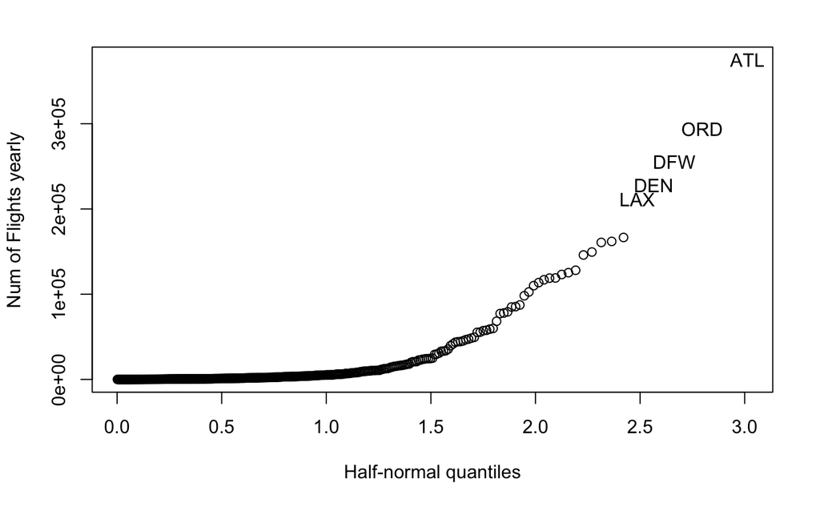

```r
ap.numflights<-ap.numflights.df$n/9.75
al.numflights<-al.numflights.df$n/9.75
#plot(x=ap.numflights,y=ap.numflights, main='Identify Major Airports', xlab='Number of Scheduled Flights Yearly',ylab='Number of Scheduled Flights Yearly')
#text(ap.numflights, ap.numflights, labels=ap.numflights.df$ORIGIN, cex = 0.5,pos=2)
halfnorm(ap.numflights,labs = ap.numflights.df$ORIGIN,ylab='Num of Flights yearly',cex=0.2, nlab = 5)
```

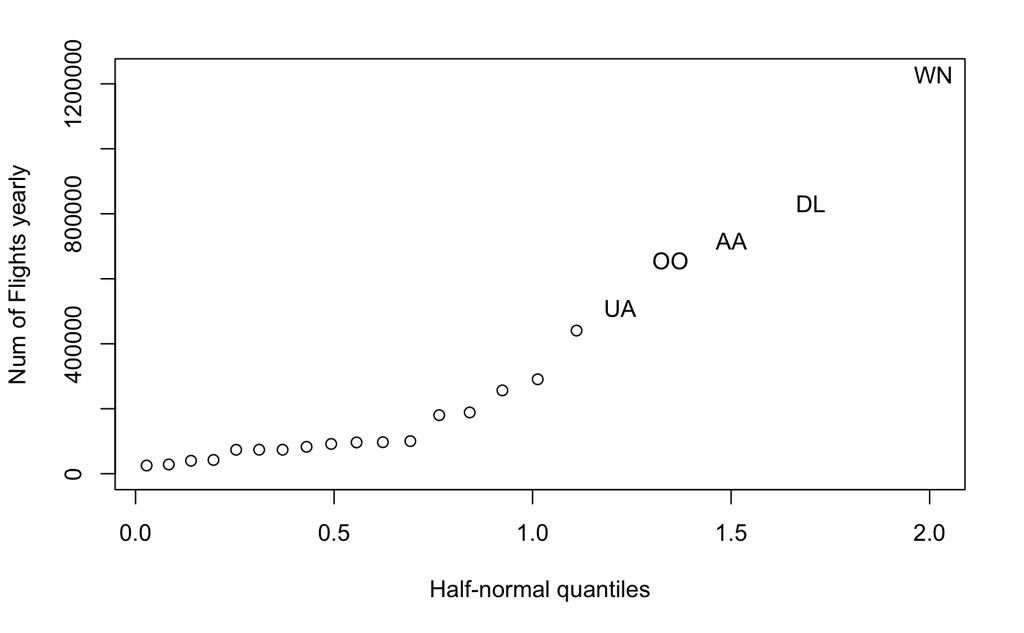

```r
halfnorm(al.numflights,labs = al.numflights.df$IATA_CODE_REPORTING_AIRLINE,ylab='Num of Flights yearly',cex= 0.2,nlab = 5)
```

```r
# set up the plot dep.timeblk.numflights.df$DEPTIMEBLK,arr.timeblk.numflights.df$ARRTIMEBLK,
plot(dep.timeblk.numflights.df$n, type="o",col='red', main="Variation of Number of Scheduled Departure/Arrival Flights In A Day", xlab='',ylab="Average Number of Flights",xaxt = "n")
axis(1,at=1:20,labels=dep.timeblk.numflights.df$DEPTIMEBLK,las=2)
```

[figure not shown]

```r
lines(arr.timeblk.numflights.df$n, type="o",col='blue')
legend(10, 200, legend=c("Departure", "Arrival"),col=c("red", "blue"), lty=1:1, cex=0.8)
```

```r
#plot(arr.timeblk.numflights.df$n, type="o", main="Variation of Number of Scheduled Arrival Flights In A Day",xlab='', ylab="Average Number of Flights",xaxt = "n")
#axis(1,at=1:20,labels=arr.timeblk.numflights.df$ARRTIMEBLK,las=2)
#barplot(height=dep.timeblk.numflights.df$n, main="Variation of Number of Scheduled Departure Flights In A Day-data", xlab="Time Block", ylab="Average Number of Flights",names.arg=dep.timeblk.numflights.df$DEPTIMEBLK)
#barplot(height=arr.timeblk.numflights.df$n, main="Variation of Number of Scheduled Arrival Flights In A Day-data", xlab="Time Block", ylab="Average Number of Flights",names.arg=arr.timeblk.numflights.df$ARRTIMEBLK)
```

```r
low.ap.numflights<-quantile(ap.numflights,0.9)
top_df<-ap.numflights.df[ap.numflights.df$n>=low.ap.numflights,]
sum(top_df$n/9.75)/sum(ap.numflights.df$n/9.75)

low.al.numflights<-quantile(al.numflights,0.9)
al.top_df<-al.numflights.df[al.numflights.df$n>=low.al.numflights,]
sum(al.top_df$n/9.75)/sum(al.numflights.df$n/9.75)
```

Overall cancel rate

```r
cancel.list<-num.cancel/num.total
```

```
There were 13 warnings (use warnings() to see them)
```

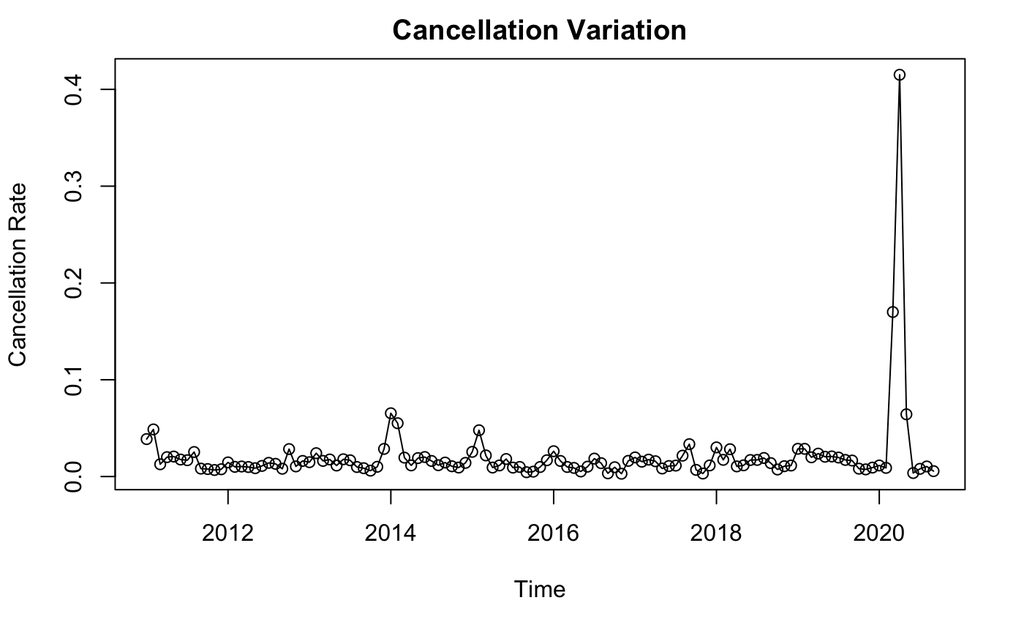

```r
cancel.series<-ts(cancel.list,start=c(2011,1),frequency=12)
plot(cancel.series,type='o',main='Cancellation Variation',ylab='Cancellation Rate')
```

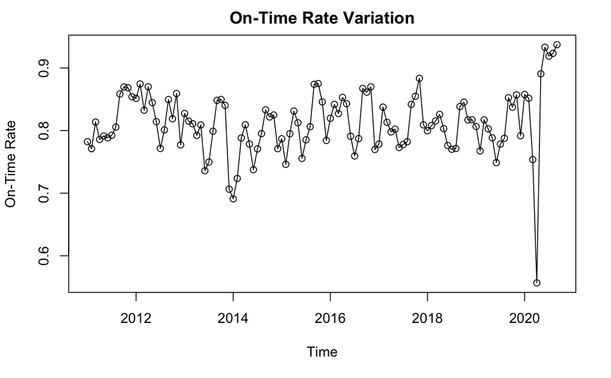

```r
ontime.list<-num.ontime/num.total
ontime.series<-ts(ontime.list,start=c(2011,1),frequency=12)
plot(ontime.series,type='o',main='On-Time Rate Variation',ylab='On-Time Rate')
```

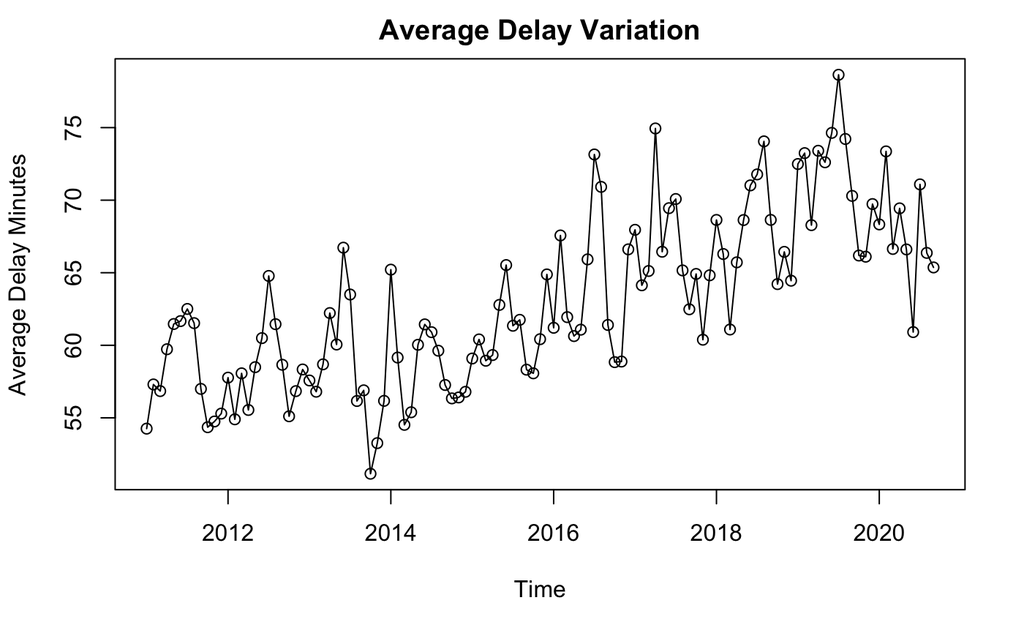

```r
avgdelay.list<-avg.delay
avgdelay.series<-ts(avgdelay.list,start=c(2011,1),frequency=12)
plot(avgdelay.series,type='o',main='Average Delay Variation',ylab='Average Delay Minutes')
```

What happen in April 2020?? ontime and cancellation is negatively correlated.

```r
part.cancel.series<-ts(cancel.list[0:108],start=c(2011,1),frequency=12)
```

```
There were 17 warnings (use warnings() to see them)
```

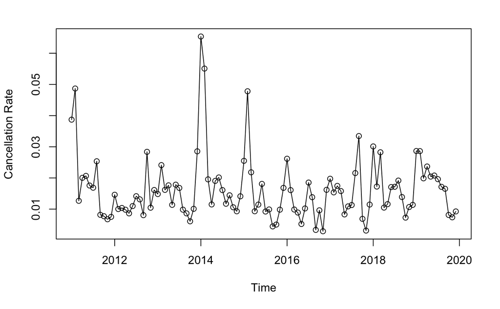

```r
plot(part.cancel.series,type='o',ylab='Cancellation Rate')
```

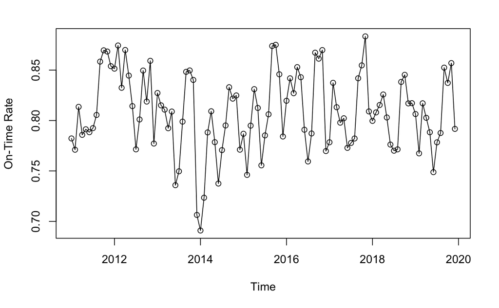

```r
part.ontime.series<-ts(ontime.list[0:108],start=c(2011,1),frequency=12)
plot(part.ontime.series,type='o',ylab='On-Time Rate')
```

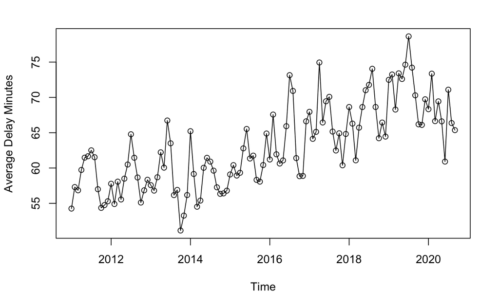

```r
avgdelay.series<-ts(avgdelay.list,start=c(2011,1),frequency=12)
plot(avgdelay.series,type='o',ylab='Average Delay Minutes')
```

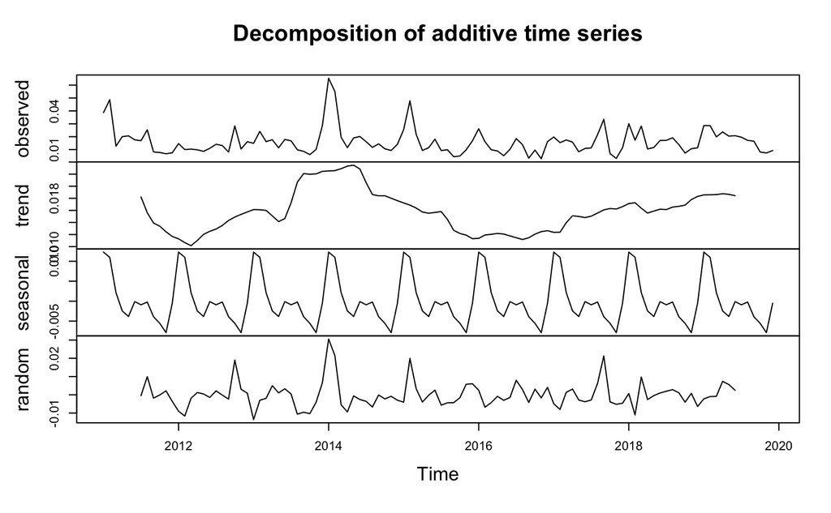

```r
components.ts = decompose(part.cancel.series)
plot(components.ts)
```

Is it stationary? kind of Invertible?

```
Title:
 KPSS Unit Root Test

Test Results:
  NA

Description:
 Tue Dec  8 07:25:48 2020 by user:
```

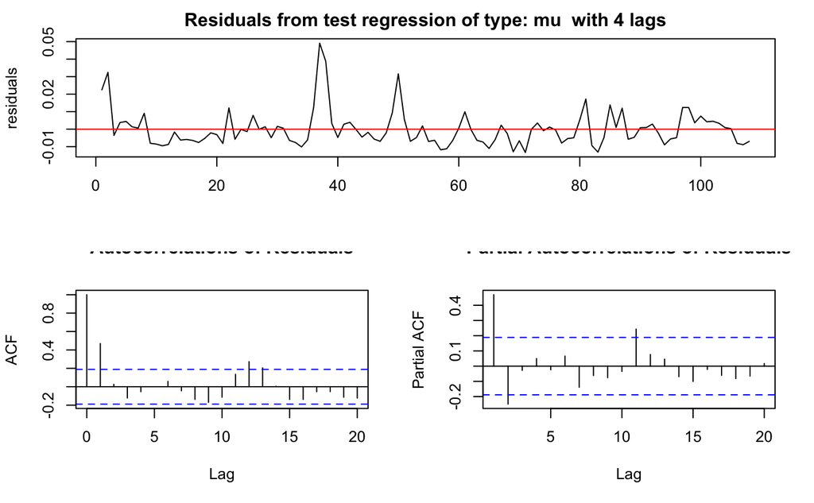

```r
library("fUnitRoots")
urkpssTest(part.cancel.series, lags = c("short"),use.lag = NULL, doplot = TRUE)
```

```r
#tsstationary = diff(tsData, differences=1) , type = c("tau")
#plot(tsstationary)
```

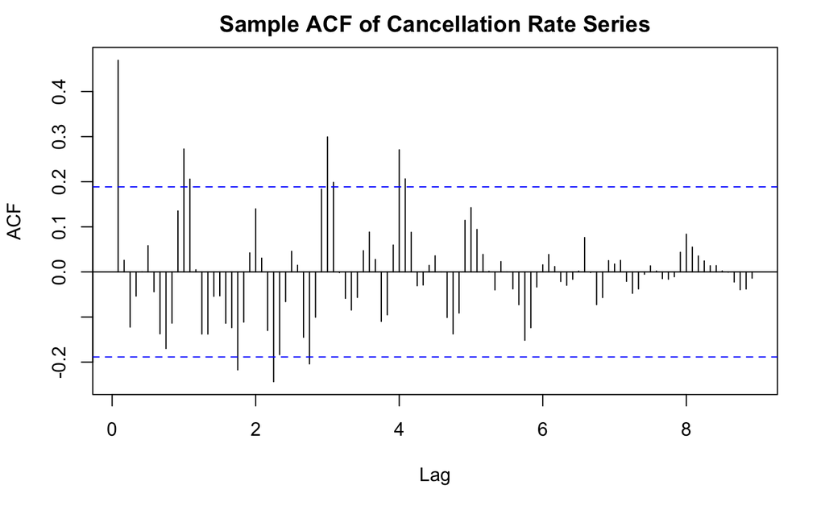

```r
acf(part.cancel.series,lag.max=108,main='Sample ACF of Cancellation Rate Series')
```

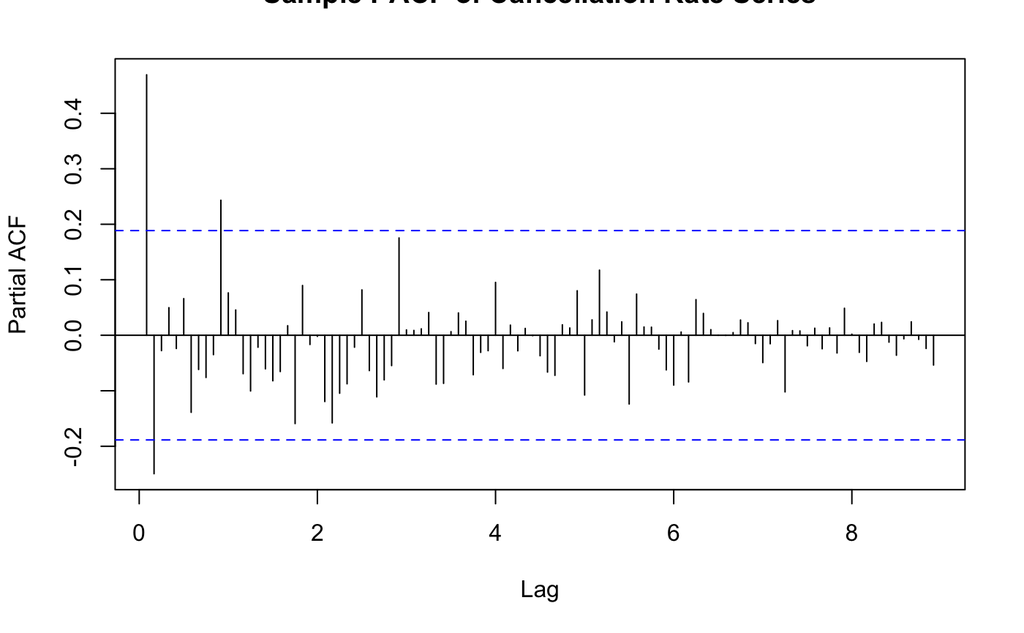

```r
pacf(part.cancel.series,lag.max=108,main='Sample PACF of Cancellation Rate Series')
```

```r
eacf(part.cancel.series)
```

```
AR/MA
  0 1 2 3 4 5 6 7 8 9 10 11 12 13
0 x o o o o o o o o o o  x  x  o
1 x o o o o o o o o o o  o  x  o
2 x x o o o o o o o o o  o  o  o
3 x o o o o o o o o o o  o  o  o
4 x x o o o o o o o o o  o  o  o
5 x o o o o o o o o o o  o  o  o
6 x o x o o o o o o o o  o  o  o
7 x x o o o o o o o o o  o  o  o
```

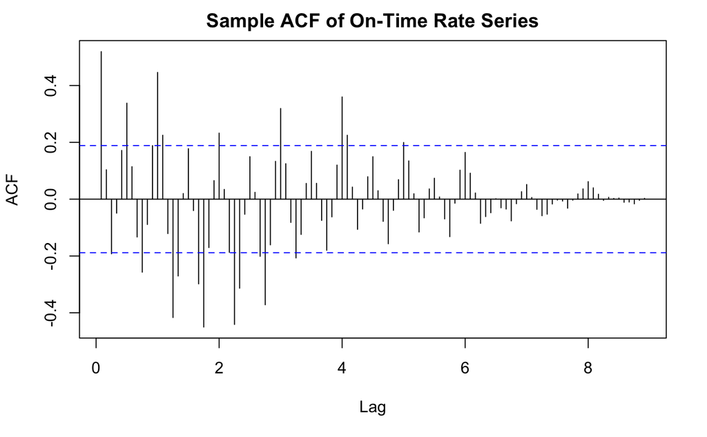

```r
acf(part.ontime.series,lag.max=108,main='Sample ACF of On-Time Rate Series')
```

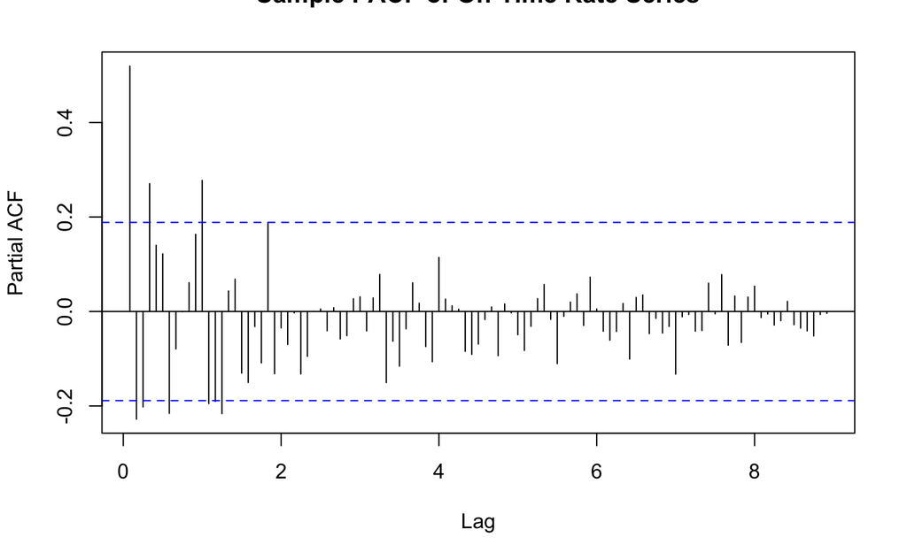

```r
pacf(part.ontime.series,lag.max=108,main='Sample PACF of On-Time Rate Series')
```

```r
eacf(part.ontime.series)
```

```
AR/MA
  0 1 2 3 4 5 6 7 8 9 10 11 12 13
0 x o o o o x o o x o o  x  x  o
1 x o x o o x o o x o o  x  x  o
2 x x o x o x o o o o o  x  o  o
3 x x o x o o o o o o o  o  o  o
4 x o x o o o o o o o o  x  o  o
5 x o x o o o o o o o o  x  o  o
6 x x x o o o o o o o o  x  o  o
7 x o x x o o o o o o o  x  o  o
```

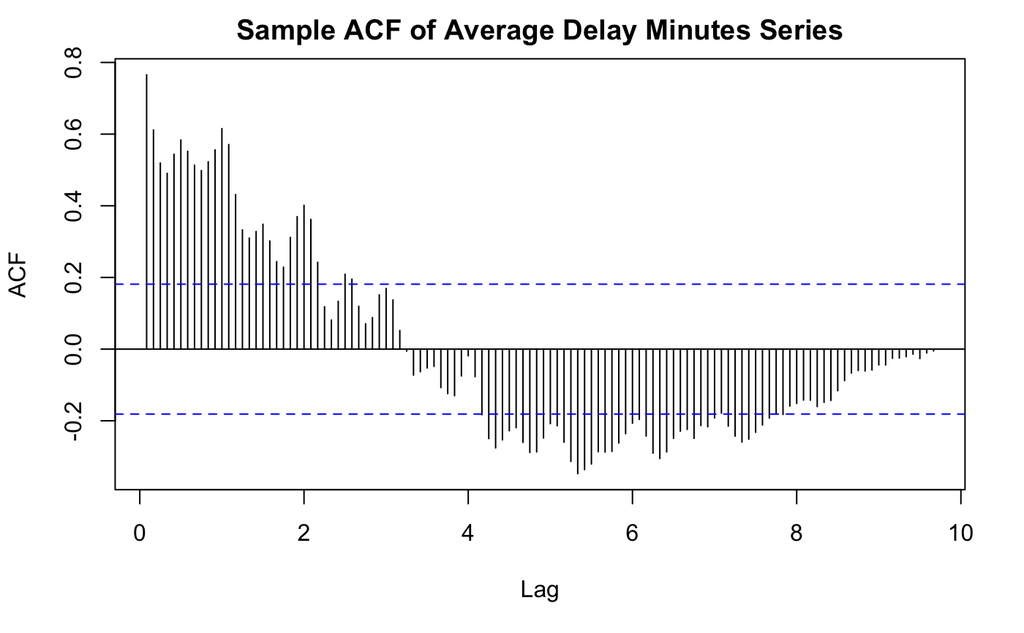

```r
acf(avgdelay.series,lag.max=117,main='Sample ACF of Average Delay Minutes Series')
```

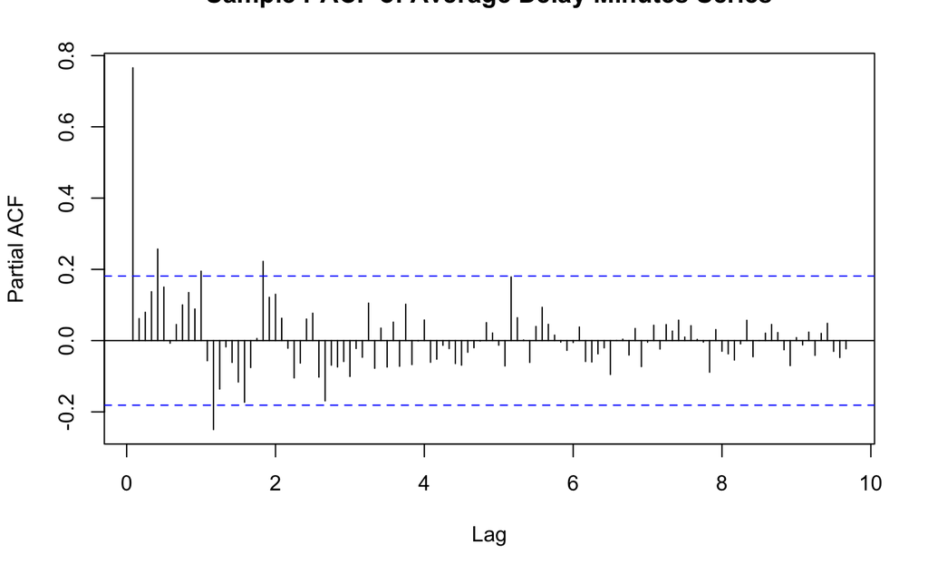

```r
pacf(avgdelay.series,lag.max=117,main='Sample PACF of Average Delay Minutes Series')
```

```r
eacf(avgdelay.series)
```

```
AR/MA
  0 1 2 3 4 5 6 7 8 9 10 11 12 13
0 x x x x x x x x x x x  x  x  x
1 o o o o o o o o o o o  x  x  o
2 x o o x o o o o o o o  o  x  o
3 x o o o o o o o o o o  o  o  o
4 x o o o o o o o o o o  o  o  o
5 x x x o x o o o o o o  o  o  o
6 o x x o x o o o o o o  o  o  o
7 x o o x o o o o o o o  o  o  o
```

```r
# aic bic
auto.arima(part.cancel.series)
```

```
Series: part.cancel.series
ARIMA(2,0,0)(1,0,0)[12] with non-zero mean

Coefficients:
         ar1      ar2    sar1    mean
      0.5457  -0.1958  0.1842  0.0164
s.e.  0.0984   0.1042  0.1074  0.0015

sigma^2 estimated as 7.624e-05:  log likelihood=360.44
AIC=-710.88   AICc=-710.29   BIC=-697.47
```

```r
d=0
aic.cancel=NULL
bic.cancel=NULL
for (p in 0:3){
  for (q in 0:4){
    aic.cancel<-c(aic.cancel,AIC(arima(part.cancel.series, order=c(p,d,q), seasonal = list(order = c(1,0,0), period = 12), method="ML")))
    bic.cancel<-c(bic.cancel,BIC(arima(part.cancel.series, order=c(p,d,q), seasonal = list(order = c(1,0,0), period = 12), method="ML")))
  }
}

aic.cancel
```

```
 [1] -687.3586 -709.6518 -711.0676 -710.1408 -708.3429 -709.4148 -709.7693 -711.4321 -709.5554 -707.6951 -710.8785 -709.0180 -709.5976 -710.5079 -708.5079
[16] -709.1491 -708.1290 -709.3919 -708.3933 -711.3695
```

```r
bic.cancel
```

```
 [1] -679.3122 -698.9232 -697.6569 -694.0480 -689.5680 -698.6863 -696.3586 -695.3393 -690.7804 -686.2380 -697.4678 -692.9252 -690.8227 -689.0508 -684.3687
[16] -693.0563 -689.3541 -687.9349 -684.2541 -684.5482
```

```r
#auto.arima(part.cancel.series)
```

Series: part.cancel.series ARIMA(2,0,0)(1,0,0)[12] with non-zero mean

Coefficients: ar1 ar2 sar1 mean 0.5457 -0.1958 0.1842 0.0164 s.e. 0.0984 0.1042 0.1074 0.0015

sigma^2 estimated as 7.624e-05: log likelihood=360.44 AIC=-710.88 AICc=-710.29 BIC=-697.47

Residual analysis

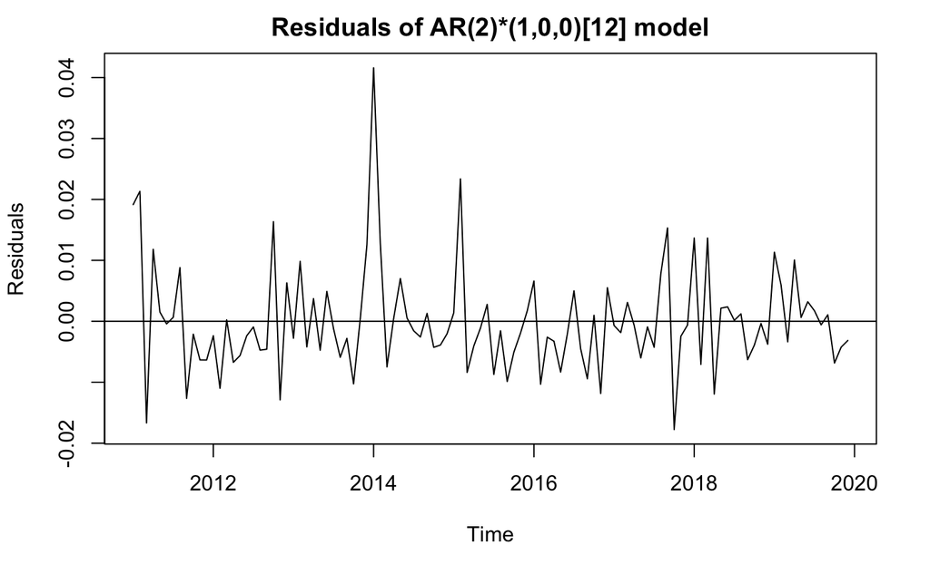

```r
cancel.model <- arima(part.cancel.series, order=c(2,0,0), seasonal = list(order = c(1,0,0), period = 12), method="ML")
cancel.residual <- residuals(cancel.model)
plot(cancel.residual, main='Residuals of AR(2)*(1,0,0)[12] model', ylab='Residuals')
abline(h=0)
```

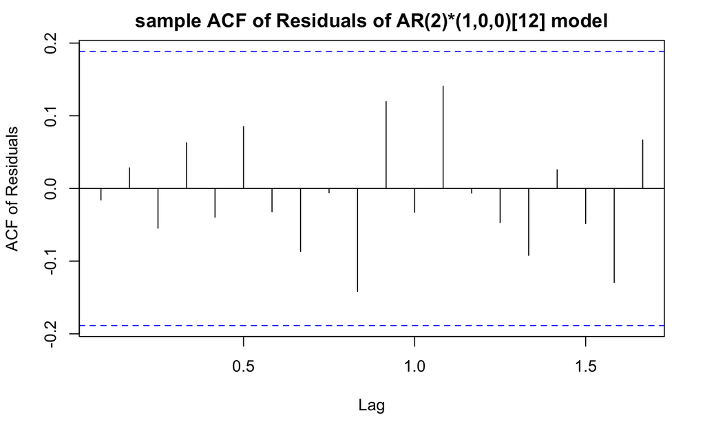

```r
acf(cancel.residual, main='sample ACF of Residuals of AR(2)*(1,0,0)[12] model', ylab='ACF of Residuals')
```

```r
LB.test(cancel.model)
```

```
    Box-Ljung test

data:  residuals from  cancel.model
X-squared = 7.276, df = 9, p-value = 0.6084
```

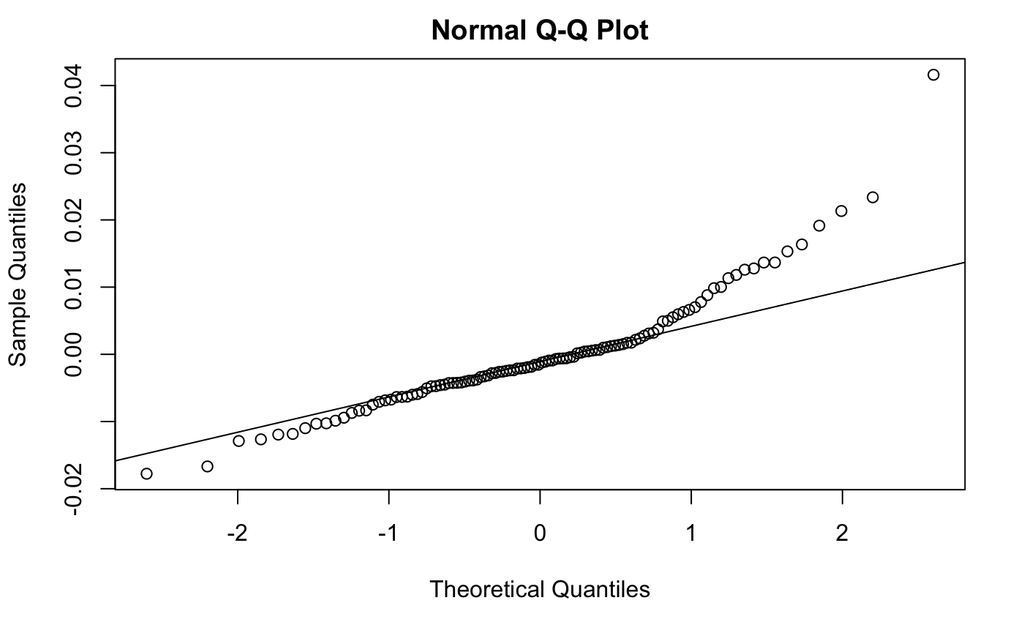

```r
qqnorm(cancel.residual)
qqline(cancel.residual)
```

```r
shapiro.test(cancel.residual)
```

```
    Shapiro-Wilk normality test

data:  cancel.residual
W = 0.90594, p-value = 1.24e-06
```

Predict

```r
fitARIMA <- arima(part.cancel.series, order=c(2,0,0), seasonal = list(order = c(1,0,0), period = 12), method="ML")
predict(fitARIMA,h=5)
```

```
$pred
            Jan
2020 0.01681046

$se
             Jan
2020 0.008568188
```

Nonstationary

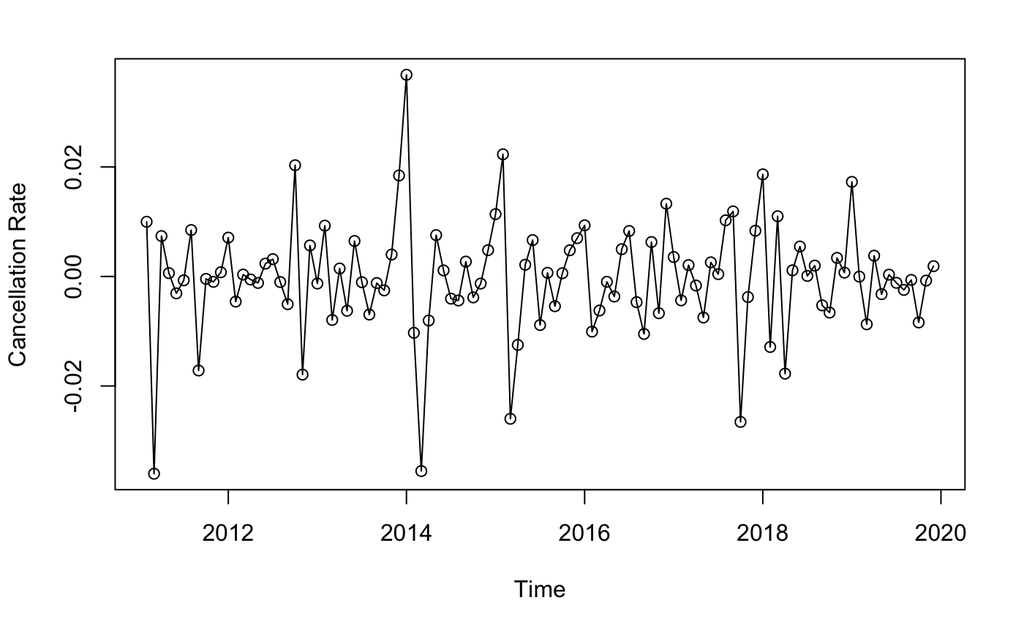

```r
part.cancel.series.D2<-diff(part.cancel.series, differences = 1)
plot(part.cancel.series.D2,type='o',ylab='Cancellation Rate')
```

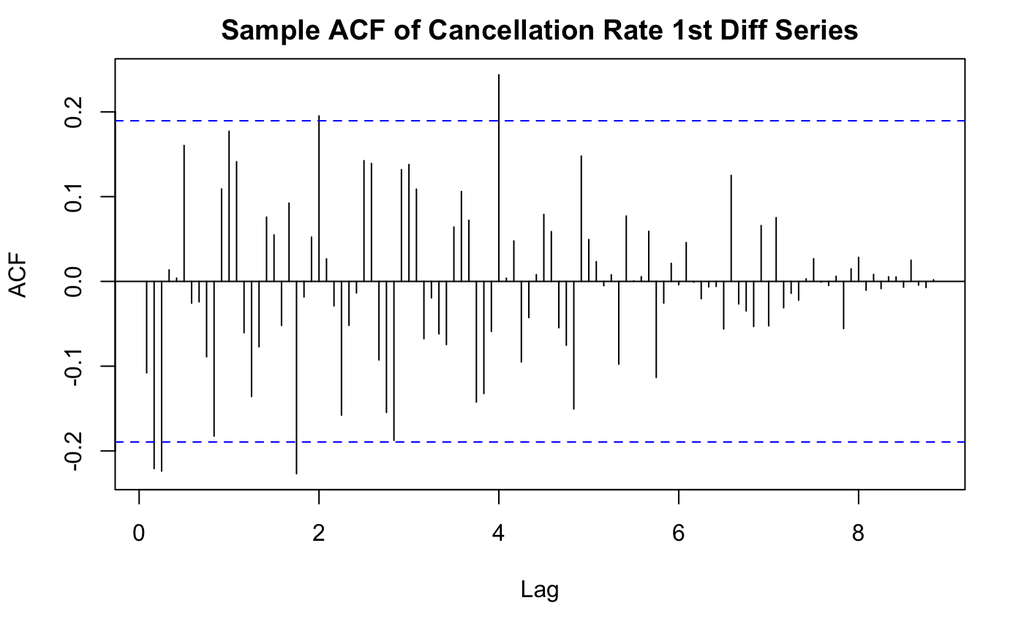

```r
acf(part.cancel.series.D2,lag.max=108,main='Sample ACF of Cancellation Rate 1st Diff Series')
```

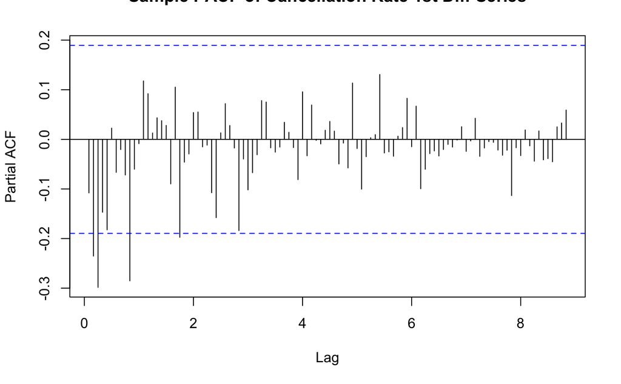

```r
pacf(part.cancel.series.D2,lag.max=108,main='Sample PACF of Cancellation Rate 1st Diff Series')
```

Average delay minutes has an upwarding trend. non stationary residual

```r
Box.test(part.cancel.series, lag=9, type="Ljung-Box")
```

```
    Box-Ljung test

data:  part.cancel.series
X-squared = 32.876, df = 9, p-value = 0.0001404
```

```r
Box.test(part.ontime.series, lag=3, type="Ljung-Box")
```

```
    Box-Ljung test

data:  part.ontime.series
X-squared = 35.322, df = 3, p-value = 1.041e-07
```

```r
Box.test(avgdelay.series, lag=4, type="Ljung-Box")
```

```
    Box-Ljung test

data:  avgdelay.series
X-squared = 178.31, df = 4, p-value < 2.2e-16
```

flights are independent ADF unit root of AIC BIC

```r
# remove leveages and outliers by airports monthly
library(dplyr)
# For cancellation

#test  select(FL_DATE,DAY_OF_WEEK,ORIGIN,ORIGIN_STATE_ABR,DEP_DELAY_NEW,DEP_TIME_BLK,TAXI_OUT,CANCELLED,DIVERTED)  group_by(ORIGIN)

#   filter(DEP_DELAY_NEW>0 & DIVERTED==0) %>%
 #  aggregate(DEP_DELAY_NEW ~ ORIGIN, data=test, FUN=median)
   # filter(n_distinct(diagnosis)==1L & diagnosis=='Anorexia Nervosa')



# Number of flights cancelled, delayed, On-Time
```